# customer_segmentation

Will Schrepferman

5/30/2020

## Introduction

This project uses k-means clustering to practice customer segmentation! It’s based off of https://data-flair.training/blogs/r-data-science-project-customer-segmentation/

Here’s what the first rows of our customer data look like:

First Few Rows of Customer Data

| customer_id | gender | age | annual_income_k | spending_score_1_100 |
| --- | --- | --- | --- | --- |
| 1 | Male | 19 | 15 | 39 |
| 2 | Male | 21 | 15 | 81 |
| 3 | Female | 20 | 16 | 6 |
| 4 | Female | 23 | 16 | 77 |
| 5 | Female | 31 | 17 | 40 |

We need to segment customers based off of their core attributes- age, spending score, and income. First, we need to know how many clusters to segment them into.

## Step 1: Identify number of clusters to use

We’ll use three methods to find this: the elbow method, average silhouette method, and gap statistics.

### Elbow method

The elbow method attempts to identify the point at which intra-cluster variation stays minimum- or where the ‘elbow’ of the measure of variation is on a graph:

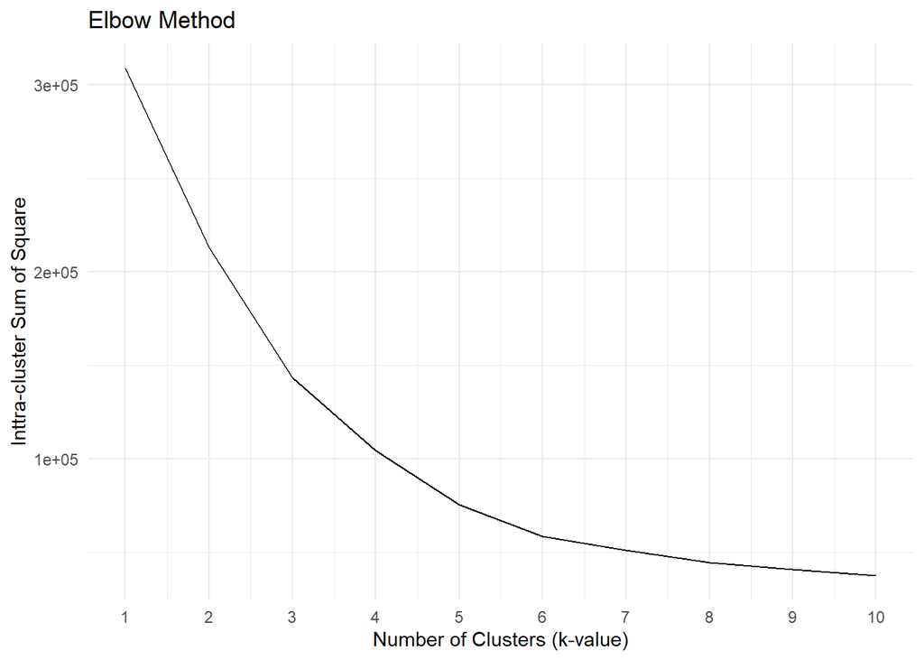

By best approximation, the ‘elbow’ seems to occur around a value of k = 4 or 5.